# Menguak Pola Harga Mobil Bekas di Jakarta

K2 Scraping | K3 Manajemen Data | K4 Eksplorasi | K5 Hubungan | K6 Seleksi Peubah

Dzulfikar Najib

# Menguak Pola Harga Mobil Bekas di Jakarta

#### Analisis Sains Data K2–K6

## Pendahuluan dan tujuan

Penelitian ini mengeksplorasi iklan mobil bekas hasil scraping OLX dengan fokus **lokasi iklan di DKI Jakarta**. Lokasi iklan bukan bukti lokasi fisik kendaraan. Data mentah tidak diubah; hasil setiap tahap disimpan terpisah. Hasil statistik di bawah bersifat eksploratif, bukan bukti sebab-akibat atau model prediksi harga.

**K2** dokumentasi scraping Python → **K3** validasi dan manajemen data → **K4** eksplorasi satu peubah → **K5** hubungan antarpeubah → **K6** filter method untuk seleksi fitur terhadap harga. Grafik dan tabel yang ditandai *bahan infografis* dapat dipakai untuk poster akhir.

## 1 Data Gathering: Proses Scraping dan Data Mentah

### 1.1 Sumber dan proses pengumpulan data

Scraping dilakukan sebelumnya menggunakan Python. R Markdown ini **tidak mengklaim menjalankan ulang scraping**; sumber analisis adalah Excel mentah yang diberikan. Pembatasan lokasi pada permintaan scraping tetap perlu divalidasi ulang karena hasil dapat memuat iklan luar Jakarta.

### 1.2 Membaca data mentah

```r
raw <- readxl::read_excel(file_raw) |> as.data.frame()
raw$ID_Mentah <- seq_len(nrow(raw))
kolom_wajib <- c("Judul","Provinsi","Kota_Kabupaten","Harga_Teks","Harga_IDR", "Merk", "Tahun", "Jarak_Tempuh", "URL_Detail")
stopifnot(all(kolom_wajib %in% names(raw)))
```

### 1.3 Audit duplikasi dan missing value

```r
knitr::kable(data.frame(Metrik=c("Observasi mentah","Jumlah peubah","URL duplikat nonkosong"), Nilai=c(nrow(raw), ncol(raw), sum(duplicated(raw$URL_Detail) & !is.na(raw$URL_Detail)))))
audit_na <- data.frame(Peubah=names(raw), Jumlah_NA=sapply(raw, function(z) sum(is.na(z) | (is.character(z) & trimws(z)==""))))
audit_na$Persen <- round(100*audit_na$Jumlah_NA/nrow(raw),1)
knitr::kable(audit_na[order(-audit_na$Jumlah_NA),], caption="Audit missing value data mentah")
knitr::kable(raw |> dplyr::count(Provinsi, sort=TRUE), caption="Provinsi pada data mentah")
```

| Metrik | Nilai |
| --- | --- |
| Observasi mentah | 4441 |
| Jumlah peubah | 20 |
| URL duplikat nonkosong | 0 |

|  | Peubah | Jumlah_NA | Persen |
| --- | --- | --- | --- |
| Tipe_Penjual | Tipe_Penjual | 369 | 8.3 |
| Kapasitas_Mesin | Kapasitas_Mesin | 357 | 8.0 |
| Tipe_Bodi | Tipe_Bodi | 245 | 5.5 |
| Judul | Judul | 0 | 0.0 |
| Kategori | Kategori | 0 | 0.0 |
| Provinsi | Provinsi | 0 | 0.0 |
| Kota_Kabupaten | Kota_Kabupaten | 0 | 0.0 |
| Kecamatan | Kecamatan | 0 | 0.0 |
| Harga_Teks | Harga_Teks | 0 | 0.0 |
| Harga_IDR | Harga_IDR | 0 | 0.0 |
| Merk | Merk | 0 | 0.0 |
| Model | Model | 0 | 0.0 |
| Tahun | Tahun | 0 | 0.0 |
| Jarak_Tempuh | Jarak_Tempuh | 0 | 0.0 |
| Tipe_Bahan_Bakar | Tipe_Bahan_Bakar | 0 | 0.0 |
| Transmisi | Transmisi | 0 | 0.0 |
| Nama_Bursa_Mobil | Nama_Bursa_Mobil | 0 | 0.0 |
| Warna | Warna | 0 | 0.0 |
| URL_Detail | URL_Detail | 0 | 0.0 |
| ID_Mentah | ID_Mentah | 0 | 0.0 |

| Provinsi | n |
| --- | --- |
| Jakarta D.K.I. | 4385 |
| Banten | 28 |
| Jawa Barat | 11 |
| Yogyakarta D.I. | 7 |
| Jawa Tengah | 5 |
| Jawa Timur | 3 |
| Sumatra Selatan | 1 |
| Sumatra Utara | 1 |

## 2 Data Management: Ekstraksi dan Pembersihan Data

Tahap ini mengubah hasil scraping menjadi data analisis. Aturan cleaning dipisahkan dari penandaan anomali supaya iklan dengan harga tinggi atau rendah tidak otomatis dianggap salah.

**Prinsip:** batasi lokasi iklan DKI, deduplikasi URL, tahan harga tidak valid atau perlu verifikasi; jangan menghapus seluruh baris hanya karena warna, bodi, penjual, atau kapasitas mesin kosong. Simpan informasi rentang sebagai rentang dan beri label ketika angka merupakan estimasi. Tidak menganggap kolom `Kecamatan` sebagai kecamatan jika identik dengan kota.

### 2.1 Fungsi ekstraksi harga, kilometer, dan kapasitas mesin

```r
parse_rupiah <- function(x) {
  s <- tolower(bersih_teks(x))
  # Hanya menerima nilai yang benar-benar berupa rupiah dengan angka, bukan teks cicilan/DP.
  s <- stringr::str_replace_all(s, "(?i)rp\\.?\\s*", "")
  s <- stringr::str_replace_all(s, "[[:space:].,]", "")
  out <- suppressWarnings(as.numeric(ifelse(stringr::str_detect(s,"^[0-9]+$"),s,NA_character_)))
  out
}
```

Fungsi berikut mengubah rentang kilometer menjadi batas bawah, batas atas, dan nilai estimasi.

```r
parse_angka_id <- function(x) suppressWarnings(as.numeric(stringr::str_replace_all(as.character(x),"[.,]","")))
parse_rentang_km <- function(x) {
  s <- tolower(bersih_teks(x))
  s <- stringr::str_replace_all(s,"(?i)km|kilometer|\\s","")
  # Titik pada kilometer adalah pemisah ribuan, bukan desimal.
  s <- stringr::str_replace_all(s,"\\.","")
  angka <- stringr::str_extract_all(s,"[0-9]+")
  n <- lengths(angka)
  lo <- hi <- rep(NA_real_,length(s))
  for(i in seq_along(s)) {
    if(n[i]==0 || is.na(s[i])) next
    a <- as.numeric(angka[[i]])
    if(stringr::str_detect(s[i],"^>")) {lo[i] <- a[1]; next}
    if(stringr::str_detect(s[i],"^<")) {hi[i] <- a[1]; next}
    lo[i] <- a[1]
    hi[i] <- if(length(a)>=2 && stringr::str_detect(s[i],"-")) a[2] else a[1]
  }
  data.frame(KM_Min=lo,KM_Max=hi, KM_Estimasi=ifelse(!is.na(lo)&!is.na(hi),(lo+hi)/2,ifelse(!is.na(lo)&is.na(hi),lo,hi)), KM_Terbuka=is.na(lo)|is.na(hi))
}
```

Kapasitas mesin yang ditulis sebagai rentang diringkas sebagai estimasi.

```r
parse_cc <- function(x) {
  s <- bersih_teks(x)
  nums <- stringr::str_extract_all(stringr::str_replace_all(s,"\\.",""),"[0-9]+")
  out <- rep(NA_real_,length(s))
  for(i in seq_along(s)) {
    if(is.na(s[i]) || !length(nums[[i]])) next
    z <- as.numeric(nums[[i]])
    if(length(z)>=2 && stringr::str_detect(s[i],"-")) out[i] <- mean(z[1:2])
    else if(!stringr::str_detect(s[i],"[<>]")) out[i] <- z[1]
  }
  out
}
```

### 2.2 Membatasi lokasi dan menghapus URL duplikat

Pemeriksaan wilayah dilakukan berdasarkan lokasi iklan yang tertulis di OLX. URL duplikat dibuang agar satu iklan tidak dihitung berulang.

```r
d <- raw |> dplyr::mutate(dplyr::across(where(is.character), bersih_teks))
n_awal <- nrow(d)
d <- d |> dplyr::filter(stringr::str_detect(stringr::str_to_lower(Provinsi),"jakarta"))
n_jakarta <- nrow(d)
# Hanya URL nonkosong yang dideduplikasi. URL kosong tidak dianggap iklan yang sama.
d <- d |> dplyr::arrange(ID_Mentah) |>
  dplyr::filter(is.na(URL_Detail) | !duplicated(URL_Detail))
n_unik <- nrow(d)
```

### 2.3 Ekstraksi fitur numerik dan indikator judul

Rentang kilometer diringkas menggunakan titik tengah sebagai estimasi. Kolom tahun digunakan untuk menghitung usia mobil; angka hasil ekstraksi tetap harus dibedakan dari spesifikasi kendaraan yang terverifikasi.

```r
km <- parse_rentang_km(d$Jarak_Tempuh)
d <- dplyr::bind_cols(d,km)
d <- d |>
  dplyr::mutate(
    Harga_Dari_Teks=parse_rupiah(Harga_Teks),
    Harga_Dari_Kolom=suppressWarnings(as.numeric(Harga_IDR)),
    Harga_Final=dplyr::coalesce(Harga_Dari_Teks,Harga_Dari_Kolom),
    Harga_Berbeda=!is.na(Harga_Dari_Teks)&!is.na(Harga_Dari_Kolom)&abs(Harga_Dari_Teks-Harga_Dari_Kolom)>1000,
    Tahun_Teks=as.character(Tahun),
    Tahun_Num=suppressWarnings(as.numeric(ifelse(stringr::str_detect(Tahun_Teks,"^[0-9]{4}$"),Tahun_Teks,NA_character_))),
    Tahun_Tidak_Pasti=is.na(Tahun_Num) & !is.na(Tahun_Teks),
    # Tahun kategori <1986 tidak diubah menjadi 1986.
    Kelompok_Tahun=dplyr::case_when(
      stringr::str_detect(dplyr::coalesce(Tahun_Teks,""),"^\\s*<\\s*1986\\s*$") ~ "Sebelum 1986",
      !is.na(Tahun_Num) & Tahun_Num < 1986 ~ "Sebelum 1986",
      !is.na(Tahun_Num) & Tahun_Num <= 1999 ~ "1986–1999",
      !is.na(Tahun_Num) & Tahun_Num <= 2009 ~ "2000–2009",
      !is.na(Tahun_Num) & Tahun_Num <= 2019 ~ "2010–2019",
      !is.na(Tahun_Num) & Tahun_Num <= 2026 ~ "2020–2026",
      TRUE ~ NA_character_
    ),
    Usia_Mobil=ifelse(!is.na(Tahun_Num)&Tahun_Num<=2026& Tahun_Num>=1900,2026-Tahun_Num,NA_real_),
    Kapasitas_CC_Estimasi=parse_cc(Kapasitas_Mesin),
    # Judul hanya digunakan untuk indikator dengan batas kata agar RS/FL tidak salah cocok.
    Is_Garansi=stringr::str_detect(Judul,stringr::regex("\\bgaransi\\b",ignore_case=TRUE)),
    Is_KM_Low=stringr::str_detect(Judul,stringr::regex("\\b(low[ -]?km|km[ -]?low|antik)\\b",ignore_case=TRUE)),
    Is_Facelift=stringr::str_detect(Judul,stringr::regex("\\b(facelift|fl|lci)\\b",ignore_case=TRUE)),
    Is_Sport_Trim=stringr::str_detect(Judul,stringr::regex("\\b(amg|trd|rs|sport|m[ -]?sport)\\b",ignore_case=TRUE)),
    Is_Promo_DP=stringr::str_detect(Judul,stringr::regex("\\b(tdp|dp[ ]*[0-9]+|dp murah)\\b",ignore_case=TRUE)),
    Harga_Juta=Harga_Final/1e6,
    Odometer_Group=cut(KM_Estimasi,c(-Inf,20000,50000,100000,Inf),labels=c("<=20 ribu","20-50 ribu","50-100 ribu",">100 ribu")),
    Lokasi_Kecamatan_Terverifikasi=ifelse(!is.na(Kecamatan)&!is.na(Kota_Kabupaten)&tolower(Kecamatan)!=tolower(Kota_Kabupaten),Kecamatan,NA_character_)
  )
```

### 2.4 Menangani tahun kendaraan yang tidak pasti

Label `<1986` menyatakan rentang tahun kendaraan, **bukan tahun posting** dan bukan tahun produksi pasti 1986. Observasi ini tetap digunakan pada analisis harga dan fitur lain, sementara `Usia_Mobil` dibiarkan `NA`. `Kelompok_Tahun` mempertahankan informasi yang masih tersedia untuk analisis kategorik.

```r
knitr::kable(d |> dplyr::count(Kelompok_Tahun,sort=TRUE),
  caption="Kelompok tahun kendaraan setelah ekstraksi")
```

Kelompok tahun kendaraan setelah ekstraksi

| Kelompok_Tahun | n |
| --- | --- |
| 2020–2026 | 2751 |
| 2010–2019 | 1191 |
| 2000–2009 | 231 |
| 1986–1999 | 198 |
| Sebelum 1986 | 14 |

### 2.5 Menandai anomali tanpa menghapus outlier otomatis

Harga di bawah Rp30 juta atau di atas Rp5 miliar hanya ditandai. Data dengan harga di bawah Rp1 juta, sumber harga yang saling bertentangan, atau indikasi uang muka ditahan dari analisis utama. Keputusan ini bersifat konservatif, bukan bukti bahwa iklan tersebut pasti keliru.

```r
# Aturan audit: harga rendah/tinggi adalah SINYAL, bukan bukti salah.
# Nilai sangat kecil (< Rp1 juta) dianggap bukan harga mobil utuh dan
# ditahan dari analisis utama karena belum dapat diverifikasi.
# Ketidaksesuaian dua sumber harga ditahan dari analisis hingga diverifikasi.
# Batas <30 juta dan >5 miliar hanya memicu pemeriksaan, TIDAK menghapus.
d <- d |> dplyr::mutate(
  Flag_Harga_Ekstrem = !is.na(Harga_Final) &
    (Harga_Final < 30000000 | Harga_Final > 5000000000),
  Flag_Harga_Tidak_Wajar = !is.na(Harga_Final) & Harga_Final < 1000000,
  Flag_Tahun = is.na(Usia_Mobil),
  Flag_Tahun_Masa_Depan = !is.na(Tahun_Num) & Tahun_Num > 2026,
  Flag_KM = is.na(KM_Estimasi) | KM_Estimasi < 0 | KM_Estimasi > 1000000,
  Flag_Potensi_DP = stringr::str_detect(
    dplyr::coalesce(Judul,""),
    stringr::regex("\\b(harga[ -]?dp|hanya[ -]?dp|dp[ :]*rp|tdp[ :]*rp)\\b",ignore_case=TRUE)),
  Flag_Log_IQR = FALSE
)
# IQR pada log harga dipakai untuk menandai, tidak menghapus otomatis.
log_harga <- log(d$Harga_Final[is.finite(d$Harga_Final) & d$Harga_Final > 0])
q_log <- stats::quantile(log_harga,c(.25,.75),na.rm=TRUE)
batas_log <- c(q_log[1]-1.5*diff(q_log),q_log[2]+1.5*diff(q_log))
d$Flag_Log_IQR <- is.finite(d$Harga_Final) & d$Harga_Final > 0 &
  (log(pmax(d$Harga_Final,1)) < batas_log[1] |
   log(pmax(d$Harga_Final,1)) > batas_log[2])
```

### 2.6 Aturan cleaning otomatis dan jejak observasi

Audit manual tidak diwajibkan. Semua baris bermasalah tetap disimpan dalam file terpisah agar keputusan cleaning transparan. Kasus harga yang hanya ekstrem secara statistik tetap dimasukkan selama tidak melanggar aturan validasi utama.

```r
d <- d |> dplyr::mutate(
  Alasan_Eksklusi = dplyr::case_when(
    is.na(Harga_Final) | !is.finite(Harga_Final) | Harga_Final<=0 ~ "Harga kosong/tidak positif",
    Flag_Tahun_Masa_Depan ~ "Tahun produksi melebihi 2026, perlu verifikasi",
    Flag_Harga_Tidak_Wajar ~ "Harga <Rp1 juta, perlu verifikasi",
    Harga_Berbeda ~ "Harga teks dan kolom berbeda, perlu verifikasi",
    Flag_Potensi_DP ~ "Indikasi harga uang muka, perlu verifikasi",
    TRUE ~ NA_character_
  ),
  Status_Anomali = dplyr::case_when(
    !is.na(Alasan_Eksklusi) ~ "Ditahan untuk verifikasi",
    Flag_Harga_Ekstrem | Flag_Log_IQR | Flag_Tahun | Flag_KM ~ "Ditandai, tetap disertakan",
    TRUE ~ "Tidak ditandai"
  )
)
review <- d |> dplyr::filter(Flag_Harga_Ekstrem | Flag_Log_IQR | Flag_Tahun | Flag_Tahun_Masa_Depan |
  Flag_KM | Harga_Berbeda | Flag_Potensi_DP | Flag_Harga_Tidak_Wajar) |>
  dplyr::select(ID_Mentah,Judul,URL_Detail,Harga_Teks,Harga_IDR,Harga_Final,
  Tahun,Jarak_Tempuh,Flag_Harga_Ekstrem,Flag_Log_IQR,Flag_Harga_Tidak_Wajar,
  Flag_Tahun,Flag_Tahun_Masa_Depan,Flag_KM,Harga_Berbeda,Flag_Potensi_DP,Status_Anomali,
  Alasan_Eksklusi)
writexl::write_xlsx(review,file.path(output_dir,"AUDIT_BARIS_PERLU_DICEK.xlsx"))
# Keluarkan hanya harga tidak valid dan kasus yang memerlukan verifikasi;
# outlier statistik, harga mobil klasik/supercar, tahun <1986 tetap ada.
managed <- d |> dplyr::filter(is.na(Alasan_Eksklusi)) |>
  dplyr::mutate(
    Tipe_Bahan_Bakar=dplyr::na_if(Tipe_Bahan_Bakar,""),
    Kapasitas_CC_Estimasi=ifelse(stringr::str_detect(tolower(dplyr::coalesce(Tipe_Bahan_Bakar,"")),"listrik|electric|ev"),NA_real_,Kapasitas_CC_Estimasi),
    Merk=dplyr::if_else(is.na(Merk),"Tidak diketahui",Merk),
    Transmisi=dplyr::if_else(is.na(Transmisi),"Tidak diketahui",Transmisi),
    Tipe_Bahan_Bakar=dplyr::if_else(is.na(Tipe_Bahan_Bakar),"Tidak diketahui",Tipe_Bahan_Bakar),
    Tipe_Bodi=dplyr::if_else(is.na(Tipe_Bodi),"Tidak diketahui",Tipe_Bodi),
    Tipe_Penjual=dplyr::if_else(is.na(Tipe_Penjual),"Tidak diketahui",Tipe_Penjual)
  )
writexl::write_xlsx(d |> dplyr::filter(!is.na(Alasan_Eksklusi)) |>
  dplyr::select(ID_Mentah,Judul,URL_Detail,Harga_Teks,Harga_IDR,Harga_Final,
    Status_Anomali,Alasan_Eksklusi),
  file.path(output_dir,"DATA_DITAHAN_ATAU_DIKELUARKAN.xlsx"))
knitr::kable(data.frame(Tahap=c("Hasil scraping","Provinsi Jakarta","URL unik/nonkosong dideduplikasi","Data analisis setelah validasi","Baris ditandai untuk pemeriksaan"),N=c(n_awal,n_jakarta,n_unik,nrow(managed),nrow(review))),caption="Jejak jumlah observasi K2-K3")
```

Jejak jumlah observasi K2-K3

| Tahap | N |
| --- | --- |
| Hasil scraping | 4441 |
| Provinsi Jakarta | 4385 |
| URL unik/nonkosong dideduplikasi | 4385 |
| Data analisis setelah validasi | 4384 |
| Baris ditandai untuk pemeriksaan | 341 |

### 2.7 Pemeriksaan akhir dan ekspor

```r
stopifnot(all(stringr::str_detect(tolower(managed$Provinsi),"jakarta")))
stopifnot(!anyDuplicated(stats::na.omit(managed$URL_Detail)))
stopifnot(all(is.finite(managed$Harga_Final) & managed$Harga_Final>0))
knitr::kable(data.frame(Variabel=names(managed),Jumlah_NA=sapply(managed,function(x)sum(is.na(x)))),caption="NA tersisa: boleh ada pada peubah yang tidak wajib")
writexl::write_xlsx(managed,file.path(output_dir,"PSD_DATA_MANAGED.xlsx"))
```

NA tersisa: boleh ada pada peubah yang tidak wajib

|  | Variabel | Jumlah_NA |
| --- | --- | --- |
| Judul | Judul | 0 |
| Kategori | Kategori | 0 |
| Provinsi | Provinsi | 0 |
| Kota_Kabupaten | Kota_Kabupaten | 0 |
| Kecamatan | Kecamatan | 0 |
| Harga_Teks | Harga_Teks | 0 |
| Harga_IDR | Harga_IDR | 0 |
| Merk | Merk | 0 |
| Model | Model | 0 |
| Tahun | Tahun | 0 |
| Jarak_Tempuh | Jarak_Tempuh | 0 |
| Tipe_Bahan_Bakar | Tipe_Bahan_Bakar | 0 |
| Transmisi | Transmisi | 0 |
| Tipe_Penjual | Tipe_Penjual | 0 |
| Nama_Bursa_Mobil | Nama_Bursa_Mobil | 0 |
| Kapasitas_Mesin | Kapasitas_Mesin | 356 |
| Warna | Warna | 0 |
| Tipe_Bodi | Tipe_Bodi | 0 |
| URL_Detail | URL_Detail | 0 |
| ID_Mentah | ID_Mentah | 0 |
| KM_Min | KM_Min | 0 |
| KM_Max | KM_Max | 54 |
| KM_Estimasi | KM_Estimasi | 0 |
| KM_Terbuka | KM_Terbuka | 0 |
| Harga_Dari_Teks | Harga_Dari_Teks | 0 |
| Harga_Dari_Kolom | Harga_Dari_Kolom | 0 |
| Harga_Final | Harga_Final | 0 |
| Harga_Berbeda | Harga_Berbeda | 0 |
| Tahun_Teks | Tahun_Teks | 0 |
| Tahun_Num | Tahun_Num | 14 |
| Tahun_Tidak_Pasti | Tahun_Tidak_Pasti | 0 |
| Kelompok_Tahun | Kelompok_Tahun | 0 |
| Usia_Mobil | Usia_Mobil | 14 |
| Kapasitas_CC_Estimasi | Kapasitas_CC_Estimasi | 1066 |
| Is_Garansi | Is_Garansi | 0 |
| Is_KM_Low | Is_KM_Low | 0 |
| Is_Facelift | Is_Facelift | 0 |
| Is_Sport_Trim | Is_Sport_Trim | 0 |
| Is_Promo_DP | Is_Promo_DP | 0 |
| Harga_Juta | Harga_Juta | 0 |
| Odometer_Group | Odometer_Group | 0 |
| Lokasi_Kecamatan_Terverifikasi | Lokasi_Kecamatan_Terverifikasi | 4384 |
| Flag_Harga_Ekstrem | Flag_Harga_Ekstrem | 0 |
| Flag_Harga_Tidak_Wajar | Flag_Harga_Tidak_Wajar | 0 |
| Flag_Tahun | Flag_Tahun | 0 |
| Flag_Tahun_Masa_Depan | Flag_Tahun_Masa_Depan | 0 |
| Flag_KM | Flag_KM | 0 |
| Flag_Potensi_DP | Flag_Potensi_DP | 0 |
| Flag_Log_IQR | Flag_Log_IQR | 0 |
| Alasan_Eksklusi | Alasan_Eksklusi | 4384 |
| Status_Anomali | Status_Anomali | 0 |

**Catatan metodologis:** Harga ekstrem hanya diberi penanda. `KM_Estimasi` adalah titik tengah rentang, bukan angka odometer pasti. `Kapasitas_CC_Estimasi` juga merupakan hasil ekstraksi. File audit otomatis disimpan untuk dokumentasi; tidak ada kewajiban mengisi template manual atau Knit ulang.

## 3 Data Exploration & Visualization

K4 hanya menggunakan data managed. Visualisasi harga menggunakan jutaan rupiah agar sumbu mudah dibaca.

### 3.1 Ringkasan statistik harga dan fitur

```r
ringkasan <- data.frame(Metrik=c("Jumlah iklan valid","Median harga (juta rupiah)","Median usia (tahun)","Median KM estimasi","Jumlah merek"),Nilai=c(nrow(managed),round(aman_median(managed$Harga_Juta),1),round(aman_median(managed$Usia_Mobil),1),round(aman_median(managed$KM_Estimasi)),dplyr::n_distinct(managed$Merk[managed$Merk!="Tidak diketahui"])))
knitr::kable(ringkasan,caption="Bahan infografis: kartu angka K4")
```

Bahan infografis: kartu angka K4

| Metrik | Nilai |
| --- | --- |
| Jumlah iklan valid | 4384 |
| Median harga (juta rupiah) | 405 |
| Median usia (tahun) | 4 |
| Median KM estimasi | 32500 |
| Jumlah merek | 62 |

### 3.2 Distribusi harga

Skala log membantu memperlihatkan distribusi harga dengan rentang yang sangat lebar tanpa menghapus mobil mahal.

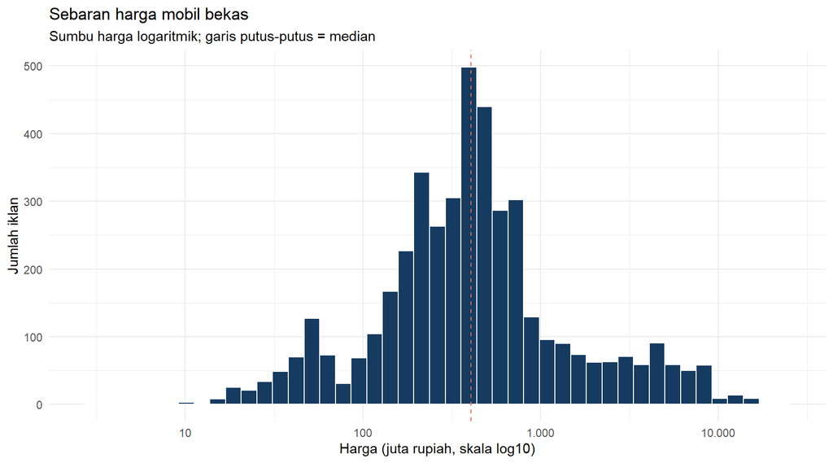

```r
p_harga <- ggplot(managed,aes(Harga_Juta))+geom_histogram(bins=45,fill=warna,color="white")+
  geom_vline(xintercept=aman_median(managed$Harga_Juta),color="#E76F51",linetype="dashed")+
  scale_x_log10(labels=scales::label_number(big.mark="."))+labs(title="Sebaran harga mobil bekas",subtitle="Sumbu harga logaritmik; garis putus-putus = median",x="Harga (juta rupiah, skala log10)",y="Jumlah iklan")+theme_minimal()
print(p_harga)
```

```r
ggsave(file.path(output_dir,"INFOGRAFIS_01_histogram_harga.png"),p_harga,width=9,height=5,dpi=220)
```

### 3.3 Distribusi kelompok tahun kendaraan

Kelompok tahun memungkinkan iklan dengan label `<1986` tetap terwakili tanpa membuat tahun produksi fiktif.

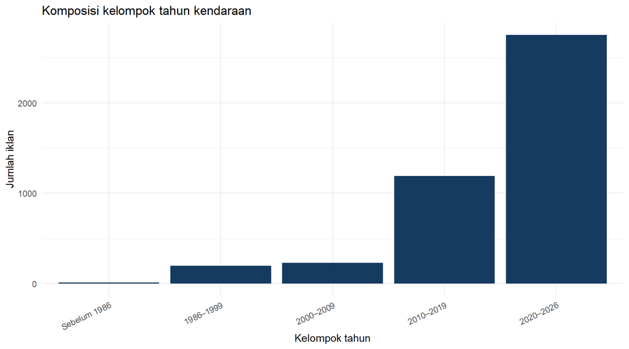

```r
urut_tahun <- c("Sebelum 1986","1986–1999","2000–2009","2010–2019","2020–2026")
p_tahun <- managed |> dplyr::filter(!is.na(Kelompok_Tahun)) |>
  dplyr::mutate(Kelompok_Tahun=factor(Kelompok_Tahun,levels=urut_tahun)) |>
  dplyr::count(Kelompok_Tahun) |>
  ggplot(aes(Kelompok_Tahun,n))+geom_col(fill=warna)+
  labs(title="Komposisi kelompok tahun kendaraan",x="Kelompok tahun",y="Jumlah iklan")+
  theme_minimal()+theme(axis.text.x=element_text(angle=25,hjust=1))
print(p_tahun)
```

```r
ggsave(file.path(output_dir,"INFOGRAFIS_06_kelompok_tahun.png"),p_tahun,width=8,height=4,dpi=220)
```

### 3.4 Komposisi merek dan kategori

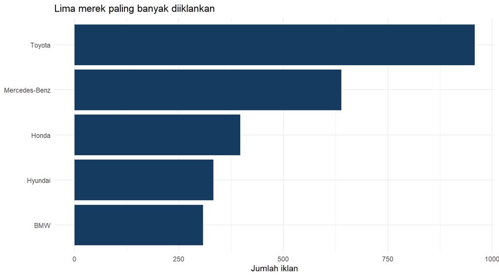

```r
top_merek <- managed |> dplyr::count(Merk,sort=TRUE) |> dplyr::slice_head(n=5)
p_merek <- ggplot(top_merek,aes(x=reorder(Merk,n),y=n))+geom_col(fill=warna)+coord_flip()+labs(title="Lima merek paling banyak diiklankan",x=NULL,y="Jumlah iklan")+theme_minimal()
print(p_merek)
```

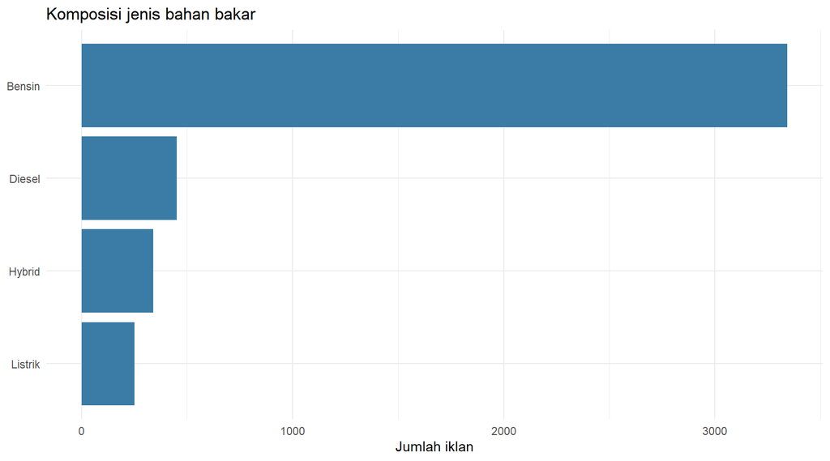

```r
ggsave(file.path(output_dir,"INFOGRAFIS_02_top_merek.png"),p_merek,width=8,height=4,dpi=220)
p_bbm <- managed |> dplyr::count(Tipe_Bahan_Bakar,sort=TRUE) |>
 ggplot(aes(x=reorder(Tipe_Bahan_Bakar,n),y=n))+geom_col(fill="#3A7CA5")+coord_flip()+labs(title="Komposisi jenis bahan bakar",x=NULL,y="Jumlah iklan")+theme_minimal()
print(p_bbm)
```

## 4 Variable Relationship: Hubungan Antarpeubah

K5 mengeksplorasi hubungan, **belum menyeleksi fitur**. Korelasi Spearman digunakan untuk hubungan monotonik numerik dan tidak mengasumsikan harga berdistribusi normal. Kruskal-Wallis dipakai untuk membandingkan distribusi harga antar kategori dengan kelompok memadai; hasil signifikan tidak membuktikan kausalitas.

### 4.1 Hubungan harga dengan peubah numerik

Scatter plot memperlihatkan pola hubungan, bukan bukti sebab-akibat.

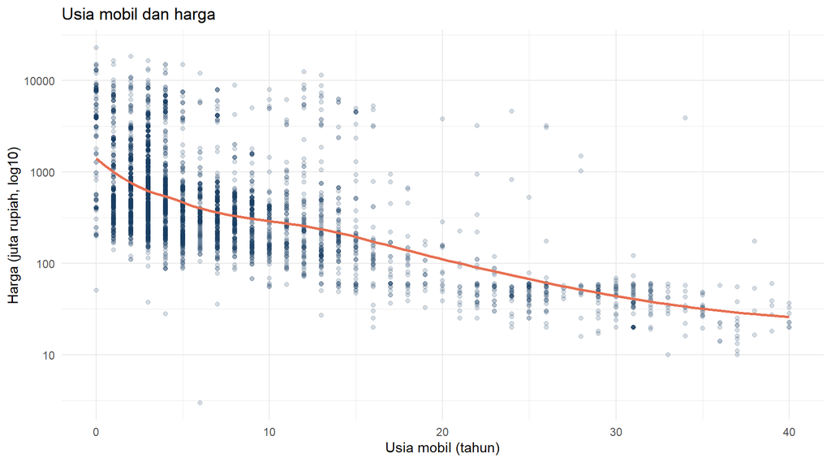

```r
p_usia <- managed |> dplyr::filter(!is.na(Usia_Mobil)) |>
 ggplot(aes(Usia_Mobil,Harga_Juta))+geom_point(alpha=.18,color=warna)+geom_smooth(method="loess",se=FALSE,color="#E76F51")+
 scale_y_log10()+labs(title="Usia mobil dan harga",x="Usia mobil (tahun)",y="Harga (juta rupiah, log10)")+theme_minimal()
print(p_usia)
```

```r
ggsave(file.path(output_dir,"INFOGRAFIS_03_usia_vs_harga.png"),p_usia,width=8,height=5,dpi=220)
num_k5 <- c("Usia_Mobil","KM_Estimasi","Kapasitas_CC_Estimasi")
korelasi <- lapply(num_k5,function(v){
 z <- managed[,c(v,"Harga_Juta")]; z <- z[stats::complete.cases(z),]
 if(nrow(z)<4 || length(unique(z[[v]]))<2) return(data.frame(Fitur=v,N=nrow(z),Spearman=NA_real_,P=NA_real_))
 t <- suppressWarnings(cor.test(z[[v]],z$Harga_Juta,method="spearman",exact=FALSE))
 data.frame(Fitur=v,N=nrow(z),Spearman=unname(t$estimate),P=t$p.value)
}) |> dplyr::bind_rows()
knitr::kable(korelasi,digits=4,caption="Korelasi Spearman terhadap harga")
```

Korelasi Spearman terhadap harga

| Fitur | N | Spearman | P |
| --- | --- | --- | --- |
| Usia_Mobil | 4370 | -0.5626 | 0 |
| KM_Estimasi | 4384 | -0.7268 | 0 |
| Kapasitas_CC_Estimasi | 3318 | 0.4944 | 0 |

### 4.2 Perbandingan harga berdasarkan kelompok tahun

Analisis ini menggunakan kategori tahun, sehingga mobil dengan tahun `<1986` tetap dapat dibandingkan. Perbedaan harga antar kelompok tidak membuktikan bahwa tahun produksi menyebabkan perubahan harga.

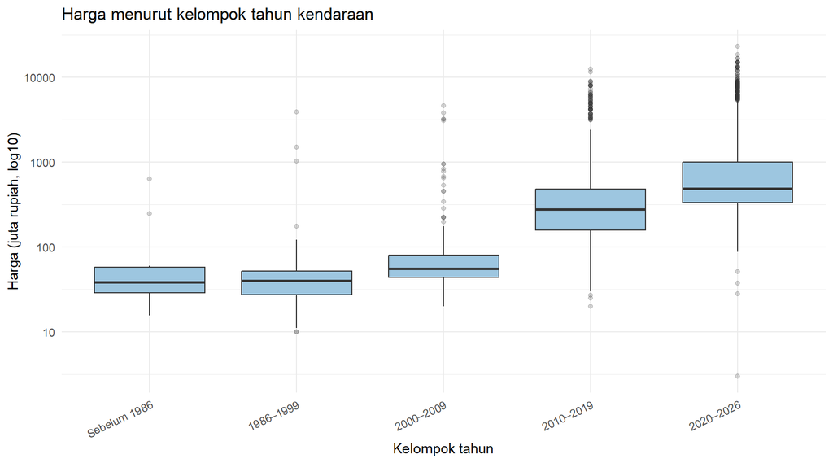

```r
p_tahun_harga <- managed |> dplyr::filter(!is.na(Kelompok_Tahun)) |>
  dplyr::mutate(Kelompok_Tahun=factor(Kelompok_Tahun,levels=urut_tahun)) |>
  ggplot(aes(Kelompok_Tahun,Harga_Juta))+geom_boxplot(fill="#9DC6E0",outlier.alpha=.2)+
  scale_y_log10()+labs(title="Harga menurut kelompok tahun kendaraan",
  x="Kelompok tahun",y="Harga (juta rupiah, log10)")+theme_minimal()+
  theme(axis.text.x=element_text(angle=25,hjust=1))
print(p_tahun_harga)
```

```r
ggsave(file.path(output_dir,"INFOGRAFIS_07_harga_kelompok_tahun.png"),p_tahun_harga,width=9,height=5,dpi=220)
```

### 4.3 Perbandingan harga antar kategori

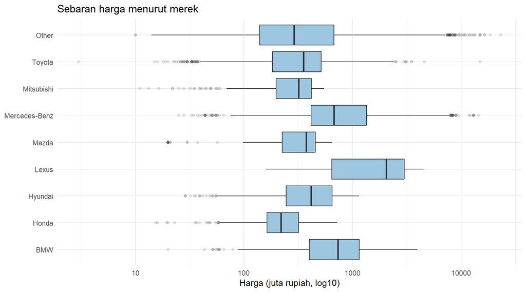

```r
# Kelompok dengan setidaknya 10 iklan agar boxplot tidak didominasi kategori langka.
merek_layak <- managed |> dplyr::count(Merk) |> dplyr::filter(n>=10) |> dplyr::pull(Merk)
p_box <- managed |> dplyr::filter(Merk %in% merek_layak) |>
 dplyr::mutate(Merk=forcats::fct_lump_n(factor(Merk),n=8)) |>
 ggplot(aes(Merk,Harga_Juta))+geom_boxplot(outlier.alpha=.12,fill="#9DC6E0")+coord_flip()+
 scale_y_log10()+labs(title="Sebaran harga menurut merek",x=NULL,y="Harga (juta rupiah, log10)")+theme_minimal()
# Jika belum memiliki forcats: instal sekali melalui install.packages("forcats")
print(p_box)
```

```r
ggsave(file.path(output_dir,"INFOGRAFIS_04_boxplot_merek.png"),p_box,width=9,height=6,dpi=220)
```

## 5 Variable Selection: Metode Filtering

Target: **Harga_Juta (numerik)**. Fitur numerik dinilai menggunakan Spearman; fitur kategorik dengan Kruskal-Wallis. Seleksi dilakukan tanpa melatih model. P-value dikoreksi menggunakan Benjamini-Hochberg untuk banyak pengujian. Fitur turunan harga, URL, judul mentah, dan variabel lokasi konstan tidak digunakan sebagai prediktor. **Hasil seleksi adalah asosiasi pada data ini, bukan peringkat sebab-akibat atau bukti performa prediksi.**

### 5.1 Pengujian statistik untuk seleksi fitur

Spearman digunakan untuk peubah numerik dan Kruskal–Wallis untuk peubah kategorik. Nilai p disesuaikan menggunakan Benjamini–Hochberg; keputusan seleksi juga mempertimbangkan besaran hubungan dan redundansi.

```r
fitur_num <- c("Usia_Mobil","KM_Estimasi","Kapasitas_CC_Estimasi")
fitur_kat <- c("Kelompok_Tahun","Merk","Transmisi","Tipe_Bahan_Bakar","Tipe_Bodi","Tipe_Penjual","Odometer_Group","Is_Garansi","Is_KM_Low","Is_Facelift","Is_Sport_Trim","Is_Promo_DP")
# Menghindari redundansi deterministik: Odometer_Group hanya eksplorasi, bukan kandidat final bila KM_Estimasi dipakai.
fitur_kat <- setdiff(fitur_kat,"Odometer_Group")
res_num <- lapply(fitur_num,function(v){
 z <- managed[,c(v,"Harga_Juta")]; z <- z[complete.cases(z),]
 if(nrow(z)<20 || length(unique(z[[v]]))<3) return(NULL)
 t <- suppressWarnings(cor.test(z[[v]],z$Harga_Juta,method="spearman",exact=FALSE))
 data.frame(Fitur=v,Jenis="Numerik",N=nrow(z),Skor=abs(unname(t$estimate)),Arah=unname(t$estimate),P=t$p.value,Ukuran="|rho Spearman|")
}) |> dplyr::bind_rows()
res_kat <- lapply(fitur_kat,function(v){
 z <- managed[,c(v,"Harga_Juta")]; z <- z[complete.cases(z),]
 tab <- table(z[[v]]); valid <- names(tab)[tab>=10]; z <- z[as.character(z[[v]]) %in% valid,]
 k <- length(unique(z[[v]])); n <- nrow(z)
 if(k<2 || n<30) return(NULL)
 t <- kruskal.test(z$Harga_Juta,as.factor(z[[v]]))
 # epsilon squared untuk Kruskal-Wallis; nolkan estimasi negatif karena fluktuasi sampel.
 eps <- max(0,(unname(t$statistic)-k+1)/(n-k))
 data.frame(Fitur=v,Jenis="Kategorik",N=n,Skor=eps,Arah=NA_real_,P=t$p.value,Ukuran="Epsilon kuadrat KW")
}) |> dplyr::bind_rows()
seleksi <- dplyr::bind_rows(res_num,res_kat)
if(!nrow(seleksi)) stop("Tidak ada fitur yang memenuhi syarat untuk diuji.")
seleksi <- seleksi |> dplyr::mutate(P_Adjust=p.adjust(P,method="BH"),Lolos=P_Adjust<0.05) |>
 dplyr::arrange(desc(Lolos),Jenis,desc(Skor))
knitr::kable(seleksi,digits=4,caption="Hasil filter method: skor numerik dan kategorik tidak boleh dibandingkan langsung")
writexl::write_xlsx(seleksi,file.path(output_dir,"HASIL_SELEKSI_FILTER.xlsx"))
```

Hasil filter method: skor numerik dan kategorik tidak boleh dibandingkan langsung

| Fitur | Jenis | N | Skor | Arah | P | Ukuran | P_Adjust | Lolos |
| --- | --- | --- | --- | --- | --- | --- | --- | --- |
| Merk | Kategorik | 4269 | 0.4206 | NA | 0.0000 | Epsilon kuadrat KW | 0.0000 | TRUE |
| Kelompok_Tahun | Kategorik | 4384 | 0.3247 | NA | 0.0000 | Epsilon kuadrat KW | 0.0000 | TRUE |
| Tipe_Bodi | Kategorik | 4361 | 0.2505 | NA | 0.0000 | Epsilon kuadrat KW | 0.0000 | TRUE |
| Transmisi | Kategorik | 4384 | 0.1781 | NA | 0.0000 | Epsilon kuadrat KW | 0.0000 | TRUE |
| Tipe_Penjual | Kategorik | 4384 | 0.0640 | NA | 0.0000 | Epsilon kuadrat KW | 0.0000 | TRUE |
| Tipe_Bahan_Bakar | Kategorik | 4384 | 0.0591 | NA | 0.0000 | Epsilon kuadrat KW | 0.0000 | TRUE |
| Is_Sport_Trim | Kategorik | 4384 | 0.0495 | NA | 0.0000 | Epsilon kuadrat KW | 0.0000 | TRUE |
| Is_Promo_DP | Kategorik | 4384 | 0.0221 | NA | 0.0000 | Epsilon kuadrat KW | 0.0000 | TRUE |
| Is_Facelift | Kategorik | 4384 | 0.0015 | NA | 0.0054 | Epsilon kuadrat KW | 0.0063 | TRUE |
| Is_Garansi | Kategorik | 4384 | 0.0012 | NA | 0.0124 | Epsilon kuadrat KW | 0.0134 | TRUE |
| Is_KM_Low | Kategorik | 4384 | 0.0009 | NA | 0.0266 | Epsilon kuadrat KW | 0.0266 | TRUE |
| KM_Estimasi | Numerik | 4384 | 0.7268 | -0.7268 | 0.0000 | \|rho Spearman\| | 0.0000 | TRUE |
| Usia_Mobil | Numerik | 4370 | 0.5626 | -0.5626 | 0.0000 | \|rho Spearman\| | 0.0000 | TRUE |
| Kapasitas_CC_Estimasi | Numerik | 3318 | 0.4944 | 0.4944 | 0.0000 | \|rho Spearman\| | 0.0000 | TRUE |

### 5.2 Visualisasi hasil filtering

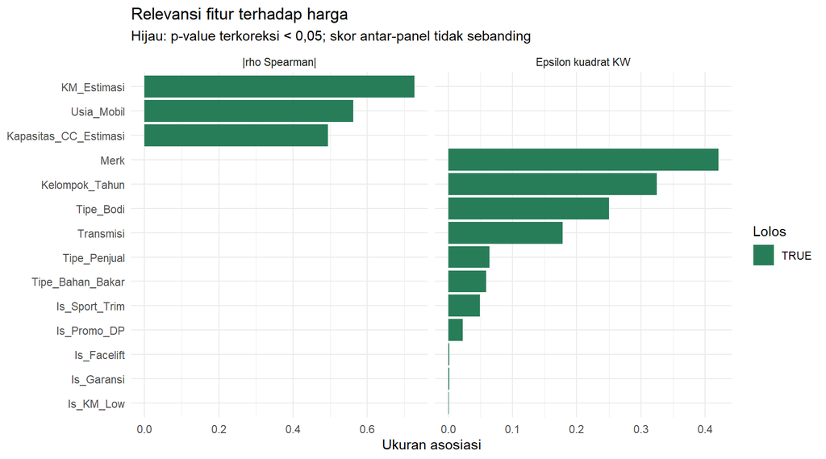

```r
# Visual terpisah menurut metode agar skala ukuran efek tidak dicampur.
p_filter <- ggplot(seleksi,aes(x=reorder(Fitur,Skor),y=Skor,fill=Lolos))+geom_col()+coord_flip()+
 facet_wrap(~Ukuran,scales="free_x")+scale_fill_manual(values=c("TRUE"="#287D59","FALSE"="#A8B4C0"))+
 labs(title="Relevansi fitur terhadap harga",subtitle="Hijau: p-value terkoreksi < 0,05; skor antar-panel tidak sebanding",x=NULL,y="Ukuran asosiasi",fill="Lolos")+theme_minimal()
print(p_filter)
```

```r
ggsave(file.path(output_dir,"INFOGRAFIS_05_seleksi_fitur.png"),p_filter,width=10,height=6,dpi=220)
fitur_lolos <- seleksi |> dplyr::filter(Lolos) |> dplyr::pull(Fitur)
cat("Fitur yang lolos kriteria statistik:",if(length(fitur_lolos))paste(fitur_lolos,collapse=", ") else "Tidak ada", "\n")
```

```
## Fitur yang lolos kriteria statistik: Merk, Kelompok_Tahun, Tipe_Bodi, Transmisi, Tipe_Penjual, Tipe_Bahan_Bakar, Is_Sport_Trim, Is_Promo_DP, Is_Facelift, Is_Garansi, Is_KM_Low, KM_Estimasi, Usia_Mobil, Kapasitas_CC_Estimasi
```

### 5.3 Pemeriksaan redundansi dan batasan seleksi

```r
num_lolos <- intersect(fitur_lolos,fitur_num)
if(length(num_lolos)>=2) {
  mat <- cor(managed[,num_lolos,drop=FALSE],method="spearman",use="pairwise.complete.obs")
  knitr::kable(round(mat,3),caption="Korelasi antarfitur numerik terpilih; |rho| >= 0,8 perlu tinjauan redundansi")
} else cat("Kurang dari dua fitur numerik lolos; matriks redundansi tidak diperlukan.")
```

Korelasi antarfitur numerik terpilih; |rho| >= 0,8 perlu tinjauan redundansi

|  | KM_Estimasi | Usia_Mobil | Kapasitas_CC_Estimasi |
| --- | --- | --- | --- |
| KM_Estimasi | 1.000 | 0.707 | -0.096 |
| Usia_Mobil | 0.707 | 1.000 | -0.027 |
| Kapasitas_CC_Estimasi | -0.096 | -0.027 | 1.000 |

Seleksi final tidak otomatis menghapus fitur hanya berdasarkan p-value: perhatikan besarnya ukuran efek, missing value, redundansi, dan pengetahuan domain. Untuk pemodelan prediktif di masa depan, pembagian train/test **harus dilakukan sebelum menghitung statistik seleksi**, lalu hasilnya diverifikasi pada data uji yang belum pernah digunakan saat seleksi.

## 6 Ringkasan untuk Infografis

Gunakan lima panel: (1) alur scraping dan cleaning beserta jumlah baris aktual dari tabel K3; (2) kartu median dan distribusi harga K4; (3) top merek serta komposisi kelompok tahun K4; (4) usia-harga dan perbandingan harga antar kelompok tahun K5; (5) hasil filter K6. Untuk tahun `<1986`, gunakan kelompok tahun, bukan usia numerik. Jangan mengisi angka infografis dari desain lama. Gambar dan file Excel keluaran tersedia di folder `hasil_analisis/` setelah Knit.

**Batasan:** data adalah iklan yang terambil pada waktu scraping, bukan seluruh pasar mobil bekas Jakarta. Harga adalah harga iklan, bukan harga transaksi. Baris dalam file audit tersedia untuk pemeriksaan jika diperlukan; rentang kilometer dan kapasitas mesin yang diubah menjadi titik tengah adalah estimasi.

### 6.1 Analisis sensitivitas harga ekstrem

Bandingkan korelasi usia-harga dan kilometer-harga pada seluruh data valid dengan subset tanpa pengamatan yang ditandai IQR log harga. **Subset hanya untuk sensitivitas**, bukan menggantikan analisis utama.

```r
cek_sensitivitas <- function(nama) {
  lapply(c("Semua data valid","Tanpa flag IQR"),function(grup) {
    z <- if(grup=="Tanpa flag IQR") managed[!managed$Flag_Log_IQR,] else managed
    z <- z[complete.cases(z[,c(nama,"Harga_Juta")]),]
    rho <- if(nrow(z)>3 && length(unique(z[[nama]]))>1)
      suppressWarnings(cor(z[[nama]],z$Harga_Juta,method="spearman")) else NA_real_
    data.frame(Fitur=nama,Skenario=grup,N=nrow(z),Rho_Spearman=rho)
  }) |> dplyr::bind_rows()
}
sensitivitas <- lapply(c("Usia_Mobil","KM_Estimasi"),cek_sensitivitas) |> dplyr::bind_rows()
knitr::kable(sensitivitas,digits=3,caption="Sensitivitas asosiasi terhadap outlier harga")
writexl::write_xlsx(sensitivitas,file.path(output_dir,"ANALISIS_SENSITIVITAS.xlsx"))
```

Sensitivitas asosiasi terhadap outlier harga

| Fitur | Skenario | N | Rho_Spearman |
| --- | --- | --- | --- |
| Usia_Mobil | Semua data valid | 4370 | -0.563 |
| Usia_Mobil | Tanpa flag IQR | 4044 | -0.546 |
| KM_Estimasi | Semua data valid | 4384 | -0.727 |
| KM_Estimasi | Tanpa flag IQR | 4054 | -0.688 |

### 6.2 Kesimpulan dan interpretasi akhir

Gunakan hasil aktual tabel dan grafik di atas untuk menulis kesimpulan. Secara khusus, catat median harga, distribusi merek, arah dan besaran korelasi usia maupun kilometer dengan harga, serta fitur yang lolos pemeriksaan filtering. Jangan menyebut hubungan statistik sebagai pengaruh kausal.

**Kesimpulan untuk infografis:** rangkum maksimal tiga temuan yang didukung angka keluaran Rmd, lalu tuliskan satu keterbatasan utama: harga OLX merupakan harga penawaran, bukan harga transaksi.